# Homework Multivariate

Armando Olivares

14 de diciembre de 2017

### Instructions:

- Apply principal component analysis (PCA), Multidimensional Scaling (MDS), and factor analysis (FA) to a real data set
- Add some descriptive analysis and make some inferences
- The data set must be the same for PCA and for FA, but different for MDS (only distance/dissimilarity information)
- Choose an application of your interest: macroeconomic variables, ﬁnance and banks, insurance companies, health care, research centers.
- Use the internet to make your own survey and data collection (open data, APIs, etc).

The Dataset selected is the **2016 County Health Rankings in the USA**, available at https://www.healthdata.gov/search/type/dataset the description of this data is in a file named: *2016 County Health Rankings Data - v3.xls* included in the folder named **data**

Load the required packages:

```r
suppressWarnings(suppressMessages(library(ggplot2)))
suppressWarnings(suppressMessages(library(plyr)))
suppressWarnings(suppressMessages(library(dplyr)))
suppressWarnings(suppressMessages(library(factoextra)))
suppressWarnings(suppressMessages(library(cluster)))
suppressWarnings(suppressMessages(library(mclust)))
suppressWarnings(suppressMessages(library(DataExplorer)))
suppressWarnings(suppressMessages(library(modeest)))
```

Read the Dataset:

```r
Dataset <- read.csv("data/2016CHR_CSV_Analytic_Data_v2.csv", header=T,  sep = ",")
```

# Exploratory Data Analysis

The size of de the datasetset

```r
dim(Dataset)
```

```
## [1] 3191  362
```

We have 3191 obs. of 362 varibles, let’s see in more detail

```r
str(Dataset)
```

```
## 'data.frame':    3191 obs. of  362 variables:
##  $ STATECODE                                                                                        : int  1 1 1 1 1 1 1 1 1 1 ...
##  $ COUNTYCODE                                                                                       : int  0 1 3 5 7 9 11 13 15 17 ...
##  $ State                                                                                            : Factor w/ 51 levels "AK","AL","AR",..: 2 2 2 2 2 2 2 2 2 2 ...
##  $ County                                                                                           : Factor w/ 1925 levels "Abbeville County",..: 10 87 94 105 155 170 231 241 254 303 ...
##  $ County.that.was.not.ranked                                                                       : int  NA NA NA NA NA NA NA NA NA NA ...
##  $ Premature.death.Value                                                                            : Factor w/ 2495 levels "","10,000","10,007",..: 2390 2293 1639 2056 241 2111 67 273 97 360 ...
##  $ Premature.death.Numerator                                                                        : Factor w/ 1437 levels "","1,001","1,004",..: 1241 1316 500 878 881 1366 392 798 449 1195 ...
##  $ Premature.death.Denominator                                                                      : Factor w/ 3010 levels "","1,004,451",..: 427 627 2208 2654 2431 677 1420 2258 1561 2947 ...
##  $ Premature.death.Lower.Confidence.Interval                                                        : Factor w/ 2430 levels "","10,028","10,029",..: 2327 2056 1572 1686 2306 1889 1947 2332 2376 57 ...
##  $ Premature.death.Upper.Confidence.Interval                                                        : Factor w/ 2597 levels "","10,000","10,001",..: 2496 39 1861 2527 620 2455 601 661 264 713 ...
##  $ Poor.or.fair.health.Value                                                                        : num  0.219 0.194 0.16 0.257 0.22 0.207 0.293 0.274 0.223 0.258 ...
##  $ Poor.or.fair.health.Numerator                                                                    : logi  NA NA NA NA NA NA ...
##  $ Poor.or.fair.health.Denominator                                                                  : logi  NA NA NA NA NA NA ...
##  $ Poor.or.fair.health.Lower.Confidence.Interval                                                    : num  0.207 0.188 0.156 0.25 0.213 0.2 0.286 0.268 0.218 0.251 ...
```

[output cut: 86 more lines]

### Basic Statistics

There is categorical and numerical variables, in order to succesful apply the PCA we need only numerical variables let’s filter the dataset to keep only numerical ones.

Let’s filter and select our data:

```r
names<- Dataset$County
Dataset <- Dataset[,sapply(Dataset, is.numeric)]
dim(Dataset)
```

```
## [1] 3191  142
```

We keep only 142(the continuous vars) out of 362

```r
str(Dataset)
```

```
## 'data.frame':    3191 obs. of  142 variables:
##  $ STATECODE                                                              : int  1 1 1 1 1 1 1 1 1 1 ...
##  $ COUNTYCODE                                                             : int  0 1 3 5 7 9 11 13 15 17 ...
##  $ County.that.was.not.ranked                                             : int  NA NA NA NA NA NA NA NA NA NA ...
##  $ Poor.or.fair.health.Value                                              : num  0.219 0.194 0.16 0.257 0.22 0.207 0.293 0.274 0.223 0.258 ...
##  $ Poor.or.fair.health.Lower.Confidence.Interval                          : num  0.207 0.188 0.156 0.25 0.213 0.2 0.286 0.268 0.218 0.251 ...
##  $ Poor.or.fair.health.Upper.Confidence.Interval                          : num  0.231 0.199 0.165 0.263 0.226 0.213 0.301 0.281 0.228 0.264 ...
##  $ Poor.physical.health.days.Value                                        : num  4.6 4.4 4.1 4.9 4.8 4.6 5.3 5.3 4.9 5.1 ...
##  $ Poor.physical.health.days.Lower.Confidence.Interval                    : num  4.4 4.2 3.9 4.7 4.6 4.4 5.2 5.2 4.8 5 ...
##  $ Poor.physical.health.days.Upper.Confidence.Interval                    : num  4.9 4.6 4.2 5 5 4.8 5.5 5.5 5.1 5.3 ...
##  $ Poor.mental.health.days.Value                                          : num  4.7 4.3 4.2 4.7 4.6 4.5 4.8 5.1 4.9 4.9 ...
##  $ Poor.mental.health.days.Lower.Confidence.Interval                      : num  4.4 4.2 4.1 4.5 4.4 4.3 4.7 4.9 4.8 4.8 ...
##  $ Poor.mental.health.days.Upper.Confidence.Interval                      : num  5 4.5 4.4 4.8 4.8 4.7 5 5.2 5.1 5.1 ...
##  $ Low.birthweight.Value                                                  : num  0.1 0.09 0.09 0.12 0.12 0.07 0.14 0.11 0.09 0.12 ...
##  $ Low.birthweight.Lower.Confidence.Interval                              : num  0.1 0.08 0.08 0.11 0.11 0.07 0.12 0.1 0.08 0.11 ...
```

[output cut: 86 more lines]

Let´s examine the Missing Values

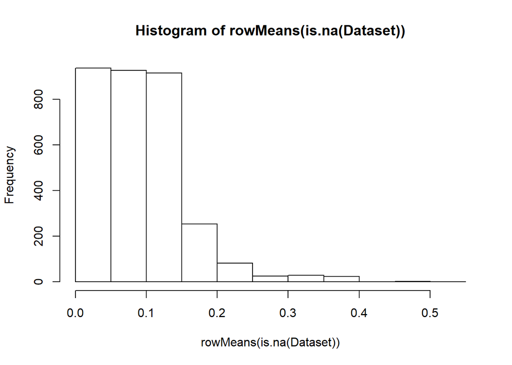

```r
# Missing values
hist(rowMeans(is.na(Dataset)))
```

Counting the NA’s by columns

```r
sapply(Dataset, function(x) sum(is.na(x)))
```

```
##                                                               STATECODE
##                                                                       0
##                                                              COUNTYCODE
##                                                                       0
##                                              County.that.was.not.ranked
##                                                                    3125
##                                               Poor.or.fair.health.Value
##                                                                       1
##                           Poor.or.fair.health.Lower.Confidence.Interval
##                                                                       3
##                           Poor.or.fair.health.Upper.Confidence.Interval
##                                                                       3
##                                         Poor.physical.health.days.Value
##                                                                       1
##                     Poor.physical.health.days.Lower.Confidence.Interval
##                                                                       3
##                     Poor.physical.health.days.Upper.Confidence.Interval
##                                                                       3
##                                           Poor.mental.health.days.Value
##                                                                       1
##                       Poor.mental.health.days.Lower.Confidence.Interval
##                                                                       3
##                       Poor.mental.health.days.Upper.Confidence.Interval
##                                                                       3
##                                                   Low.birthweight.Value
##                                                                      99
##                               Low.birthweight.Lower.Confidence.Interval
##                                                                     218
##                               Low.birthweight.Upper.Confidence.Interval
##                                                                     218
##                                                     Adult.smoking.Value
##                                                                       1
##                                 Adult.smoking.Lower.Confidence.Interval
##                                                                       3
##                                 Adult.smoking.Upper.Confidence.Interval
##                                                                       3
##                                                     Adult.obesity.Value
##                                                                       0
##                                 Adult.obesity.Lower.Confidence.Interval
##                                                                      52
```

[output cut: 229 more lines]

```
##                                                                     116
##                                             Rank.for.Variable.MORTALITY
##                                                                     116
##                                             Rank.for.Variable.MORBIDITY
##                                                                     116
##                                                    Rank.for.Variable.HF
##                                                                     116
##                                                    Rank.for.Variable.HB
##                                                                     116
##                                                    Rank.for.Variable.CC
##                                                                     116
##                                                    Rank.for.Variable.SF
##                                                                     116
##                                                    Rank.for.Variable.PE
##                                                                     116
```

The Column *County.that.was.not.ranked* has a lot of NA and this columns not adding to much informaction so we decide to delete it.

```r
Dataset$County.that.was.not.ranked <- NULL
```

Also in our dataset there are columns of interval, we don’t care about these columns so we filter it

```r
Dataset <-select(Dataset, -contains("Confidence"))
```

We keep 70 variables from origin 362

```r
summary(Dataset)
```

```
##    STATECODE       COUNTYCODE    Poor.or.fair.health.Value
##  Min.   : 1.00   Min.   :  0.0   Min.   :0.0720
##  1st Qu.:18.00   1st Qu.: 33.0   1st Qu.:0.1300
##  Median :29.00   Median : 77.0   Median :0.1590
##  Mean   :30.29   Mean   :102.1   Mean   :0.1691
##  3rd Qu.:45.00   3rd Qu.:133.0   3rd Qu.:0.2000
##  Max.   :56.00   Max.   :840.0   Max.   :0.4170
##                                  NA's   :1
##  Poor.physical.health.days.Value Poor.mental.health.days.Value
##  Min.   :2.200                   Min.   :2.100
##  1st Qu.:3.300                   1st Qu.:3.200
##  Median :3.700                   Median :3.700
##  Mean   :3.807                   Mean   :3.674
##  3rd Qu.:4.300                   3rd Qu.:4.100
##  Max.   :6.500                   Max.   :5.600
##  NA's   :1                       NA's   :1
##  Low.birthweight.Value Adult.smoking.Value Adult.obesity.Value
##  Min.   :0.03000       Min.   :0.069       Min.   :0.1070
##  1st Qu.:0.07000       1st Qu.:0.157       1st Qu.:0.2850
##  Median :0.08000       Median :0.178       Median :0.3110
##  Mean   :0.08177       Mean   :0.184       Mean   :0.3090
##  3rd Qu.:0.09000       3rd Qu.:0.207       3rd Qu.:0.3365
##  Max.   :0.28000       Max.   :0.412       Max.   :0.4660
##  NA's   :99            NA's   :1
##  Food.environment.index.Value Physical.inactivity.Value
##  Min.   : 0.000               Min.   :0.091
##  1st Qu.: 6.400               1st Qu.:0.238
##  Median : 7.200               Median :0.276
##  Mean   : 6.962               Mean   :0.273
##  3rd Qu.: 7.800               3rd Qu.:0.309
##  Max.   :10.000               Max.   :0.417
##
##  Access.to.exercise.opportunities.Value Excessive.drinking.Value
##  Min.   :0.0000                         Min.   :0.0840
##  1st Qu.:0.4370                         1st Qu.:0.1420
##  Median :0.6260                         Median :0.1660
##  Mean   :0.5962                         Mean   :0.1659
##  3rd Qu.:0.7770                         3rd Qu.:0.1900
##  Max.   :1.0000                         Max.   :0.2730
##  NA's   :74                             NA's   :1
```

[output cut: 257 more lines]

```
##  Min.   :  1.00       Min.   :  1.00       Min.   :  1.00
##  1st Qu.: 17.00       1st Qu.: 17.00       1st Qu.: 17.00
##  Median : 38.00       Median : 38.00       Median : 38.00
##  Mean   : 47.65       Mean   : 47.65       Mean   : 47.65
##  3rd Qu.: 66.00       3rd Qu.: 66.00       3rd Qu.: 66.00
##  Max.   :241.00       Max.   :241.00       Max.   :241.00
##  NA's   :116          NA's   :116          NA's   :116
##  Rank.for.Variable.SF Rank.for.Variable.PE
##  Min.   :  1.00       Min.   :  1.00
##  1st Qu.: 17.00       1st Qu.: 17.00
##  Median : 38.00       Median : 38.00
##  Mean   : 47.65       Mean   : 47.65
##  3rd Qu.: 66.00       3rd Qu.: 66.00
##  Max.   :241.00       Max.   :241.00
##  NA's   :116          NA's   :116
```

We will examine the columns that contains NA’s in order to decide what to do with them

```r
names(Dataset)
```

```
##  [1] "STATECODE"
##  [2] "COUNTYCODE"
##  [3] "Poor.or.fair.health.Value"
##  [4] "Poor.physical.health.days.Value"
##  [5] "Poor.mental.health.days.Value"
##  [6] "Low.birthweight.Value"
##  [7] "Adult.smoking.Value"
##  [8] "Adult.obesity.Value"
##  [9] "Food.environment.index.Value"
## [10] "Physical.inactivity.Value"
## [11] "Access.to.exercise.opportunities.Value"
## [12] "Excessive.drinking.Value"
## [13] "Alcohol.impaired.driving.deaths.Value"
## [14] "Teen.births.Value"
## [15] "Uninsured.Value"
```

[output cut: 55 more lines]

We only want certains columns that could be representative to our Study we will filter the meaninless columns like *COUNTYCODE, STATECODE and the Colummns names as Rank*

```r
Dataset_num <- Dataset[, -c(1,2,9,13,21,22,25,27,30,31,32,33,34, 43,44,48:70)]
```

The missing Values:

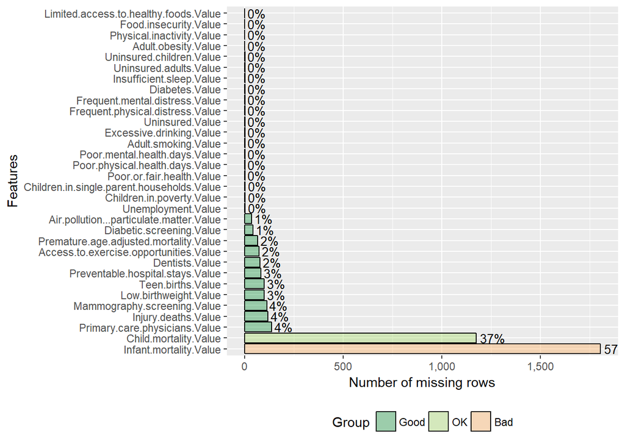

```r
 PlotMissing(Dataset_num)
```

```r
sapply(Dataset_num, function(x) sum(is.na(x)))
```

```
##                  Poor.or.fair.health.Value
##                                          1
##            Poor.physical.health.days.Value
##                                          1
##              Poor.mental.health.days.Value
##                                          1
##                      Low.birthweight.Value
##                                         99
##                        Adult.smoking.Value
##                                          1
##                        Adult.obesity.Value
##                                          0
##                  Physical.inactivity.Value
##                                          0
##     Access.to.exercise.opportunities.Value
##                                         74
##                   Excessive.drinking.Value
##                                          1
##                          Teen.births.Value
##                                         99
##                            Uninsured.Value
##                                          1
##              Primary.care.physicians.Value
##                                        137
##                             Dentists.Value
##                                         78
##           Preventable.hospital.stays.Value
##                                         83
##                   Diabetic.screening.Value
##                                         42
##                Mammography.screening.Value
##                                        112
##                         Unemployment.Value
##                                          2
##                  Children.in.poverty.Value
##                                          2
## Children.in.single.parent.households.Value
##                                          2
##                        Injury.deaths.Value
##                                        117
```

[output cut: 9 more lines]

```
##                                          1
##             Frequent.mental.distress.Value
##                                          1
##                             Diabetes.Value
##                                          1
##                      Food.insecurity.Value
##                                          0
##      Limited.access.to.healthy.foods.Value
##                                          0
##                   Insufficient.sleep.Value
##                                          1
##                     Uninsured.adults.Value
##                                          1
##                   Uninsured.children.Value
##                                          1
```

To process the NA’s we decide to impute to 0 the columns with only 1 NA, for example *Uninsured.adult.value*

```r
Dataset_num[,names(which(sapply(Dataset_num, function(x) sum(is.na(x))<5)))][is.na(Dataset_num[,names(which(sapply(Dataset_num, function(x) sum(is.na(x))<5)))])]<-0
Dataset_num$Children.in.poverty.Value[is.na(Dataset_num$Children.in.poverty.Value)] <- 0
Dataset_num$Infant.mortality.Value[is.na(Dataset_num$Infant.mortality.Value)] <- 0
Dataset_num$Child.mortality.Value[is.na(Dataset_num$Child.mortality.Value)] <- 0
Dataset_num$Injury.deaths.Value[is.na(Dataset_num$Injury.deaths.Value)] <- 0
```

Check again the columns

```r
sapply(Dataset_num, function(x) sum(is.na(x)))
```

```
##                  Poor.or.fair.health.Value
##                                          0
##            Poor.physical.health.days.Value
##                                          0
##              Poor.mental.health.days.Value
##                                          0
##                      Low.birthweight.Value
##                                         99
##                        Adult.smoking.Value
##                                          0
##                        Adult.obesity.Value
##                                          0
##                  Physical.inactivity.Value
##                                          0
##     Access.to.exercise.opportunities.Value
##                                         74
##                   Excessive.drinking.Value
##                                          0
##                          Teen.births.Value
##                                         99
##                            Uninsured.Value
##                                          0
##              Primary.care.physicians.Value
##                                        137
##                             Dentists.Value
##                                         78
##           Preventable.hospital.stays.Value
##                                         83
##                   Diabetic.screening.Value
##                                         42
##                Mammography.screening.Value
##                                        112
##                         Unemployment.Value
##                                          0
##                  Children.in.poverty.Value
##                                          0
## Children.in.single.parent.households.Value
##                                          0
##                        Injury.deaths.Value
##                                          0
```

[output cut: 9 more lines]

```
##                                          0
##             Frequent.mental.distress.Value
##                                          0
##                             Diabetes.Value
##                                          0
##                      Food.insecurity.Value
##                                          0
##      Limited.access.to.healthy.foods.Value
##                                          0
##                   Insufficient.sleep.Value
##                                          0
##                     Uninsured.adults.Value
##                                          0
##                   Uninsured.children.Value
##                                          0
```

Now we will impute the remain NA’s with the most comun value of the columns

```r
Dataset_num$Low.birthweight.Value[is.na(Dataset_num$Low.birthweight.Value)] <- mlv(as.numeric(Dataset_num$Low.birthweight.Value), na.rm = T, method = "mfv")[1]
Dataset_num$Teen.births.Value[is.na(Dataset_num$Teen.births.Value)] <- mlv(as.numeric(Dataset_num$Teen.births.Value), na.rm = T, method = "mfv")[1]
Dataset_num$Primary.care.physicians.Value[is.na(Dataset_num$Primary.care.physicians.Value)] <- mlv(as.numeric(Dataset_num$Primary.care.physicians.Value), na.rm = T, method = "mfv")[1]
Dataset_num$Preventable.hospital.stays.Value[is.na(Dataset_num$Preventable.hospital.stays.Value)] <- mlv(as.numeric(Dataset_num$Preventable.hospital.stays.Value), na.rm = T, method = "mfv")[1]
Dataset_num$Mammography.screening.Value[is.na(Dataset_num$Mammography.screening.Value)] <- mlv(as.numeric(Dataset_num$Mammography.screening.Value), na.rm = T, method = "mfv")[1]
Dataset_num$Premature.age.adjusted.mortality.Value[is.na(Dataset_num$Premature.age.adjusted.mortality.Value)] <- mlv(as.numeric(Dataset_num$Premature.age.adjusted.mortality.Value), na.rm = T, method = "mfv")[1]
Dataset_num$Air.pollution...particulate.matter.Value[is.na(Dataset_num$Air.pollution...particulate.matter.Value)] <- mean(as.numeric(Dataset_num$Air.pollution...particulate.matter.Value), na.rm = T, method = "mfv")[1]
Dataset_num$Dentists.Value[is.na(Dataset_num$Dentists.Value)] <- mlv(as.numeric(Dataset_num$Dentists.Value), na.rm = T, , method = "mfv")[1]
Dataset_num$Diabetic.screening.Value[is.na(Dataset_num$Diabetic.screening.Value)] <- mlv(as.numeric(Dataset_num$Diabetic.screening.Value), na.rm = T, method = "mfv")[1]
Dataset_num$Dentists.Value[is.na(Dataset_num$Dentists.Value)] <- mlv(as.numeric(Dataset_num$Dentists.Value), na.rm = T, method = "mfv")[1]
Dataset_num$Access.to.exercise.opportunities.Value[is.na(Dataset_num$Access.to.exercise.opportunities.Value)] <- mlv(as.numeric(Dataset_num$Access.to.exercise.opportunities.Value), na.rm = T, method = "mfv")[1]
```

Now, to properly apply PCA the columns must have certain level of lineal correlation, so we will check the correlation through the heatmap:

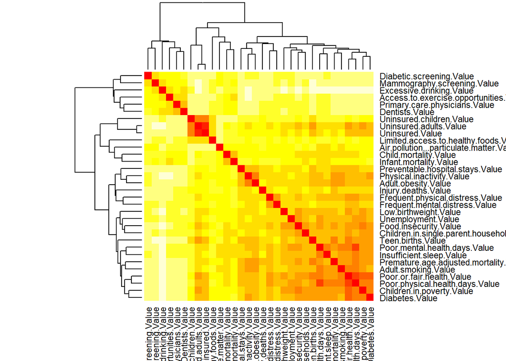

```r
Dataset_num <- as.data.frame(sapply(Dataset_num, as.numeric))
R = cor(Dataset_num)
heatmap(sqrt(2*(1-R)), symm = TRUE )
```

Another look of the correlation among variables:

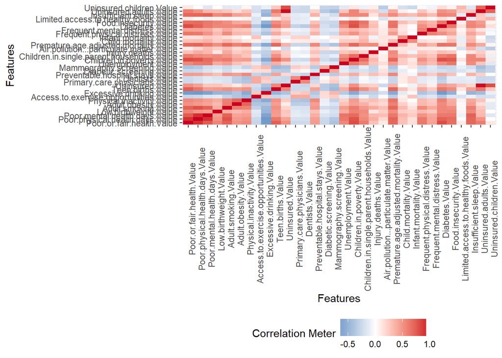

```r
CorrelationContinuous(Dataset_num)
```

there is certain level of correlation as we see in the heatmap

### Is time to apply the PCA Method:

```r
pca = prcomp(Dataset_num, scale=T)

summary(pca)
```

```
## Importance of components%s:
##                           PC1    PC2     PC3     PC4    PC5     PC6
## Standard deviation     3.4795 1.9094 1.53842 1.17997 1.1454 1.04338
## Proportion of Variance 0.3783 0.1139 0.07396 0.04351 0.0410 0.03402
## Cumulative Proportion  0.3783 0.4923 0.56623 0.60974 0.6507 0.68476
##                            PC7    PC8     PC9    PC10    PC11   PC12
## Standard deviation     0.97192 0.9244 0.89225 0.88282 0.82140 0.7939
## Proportion of Variance 0.02952 0.0267 0.02488 0.02436 0.02108 0.0197
## Cumulative Proportion  0.71428 0.7410 0.76587 0.79022 0.81131 0.8310
##                           PC13    PC14    PC15    PC16    PC17    PC18
## Standard deviation     0.75220 0.73282 0.70006 0.67433 0.63675 0.62587
## Proportion of Variance 0.01768 0.01678 0.01532 0.01421 0.01267 0.01224
## Cumulative Proportion  0.84869 0.86547 0.88078 0.89499 0.90766 0.91990
##                           PC19    PC20    PC21    PC22    PC23    PC24
## Standard deviation     0.59276 0.57815 0.56448 0.54138 0.47805 0.46676
## Proportion of Variance 0.01098 0.01045 0.00996 0.00916 0.00714 0.00681
## Cumulative Proportion  0.93088 0.94133 0.95129 0.96045 0.96759 0.97440
##                           PC25    PC26   PC27    PC28    PC29    PC30
## Standard deviation     0.42594 0.39919 0.3918 0.35556 0.31745 0.26895
## Proportion of Variance 0.00567 0.00498 0.0048 0.00395 0.00315 0.00226
## Cumulative Proportion  0.98007 0.98505 0.9898 0.99379 0.99694 0.99920
##                           PC31    PC32
## Standard deviation     0.15334 0.04463
## Proportion of Variance 0.00073 0.00006
## Cumulative Proportion  0.99994 1.00000
```

The first and second component can explain about 49% of the variance of our dataset (no bad for having around 32 variables)

### Now let’s examine the components

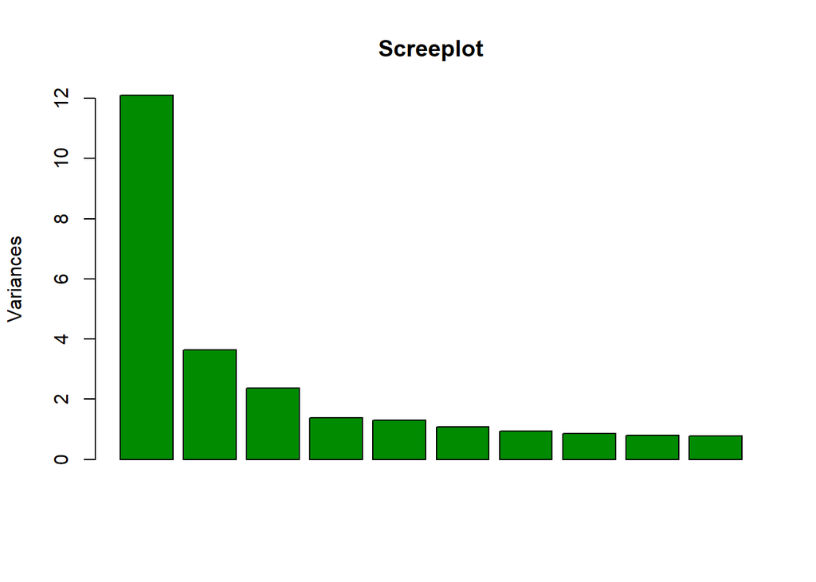

```r
screeplot(pca,main="Screeplot",col="green4",type="barplot",pch=19)
```

as we hope the main component is the first one, it capture the most information

In more details:

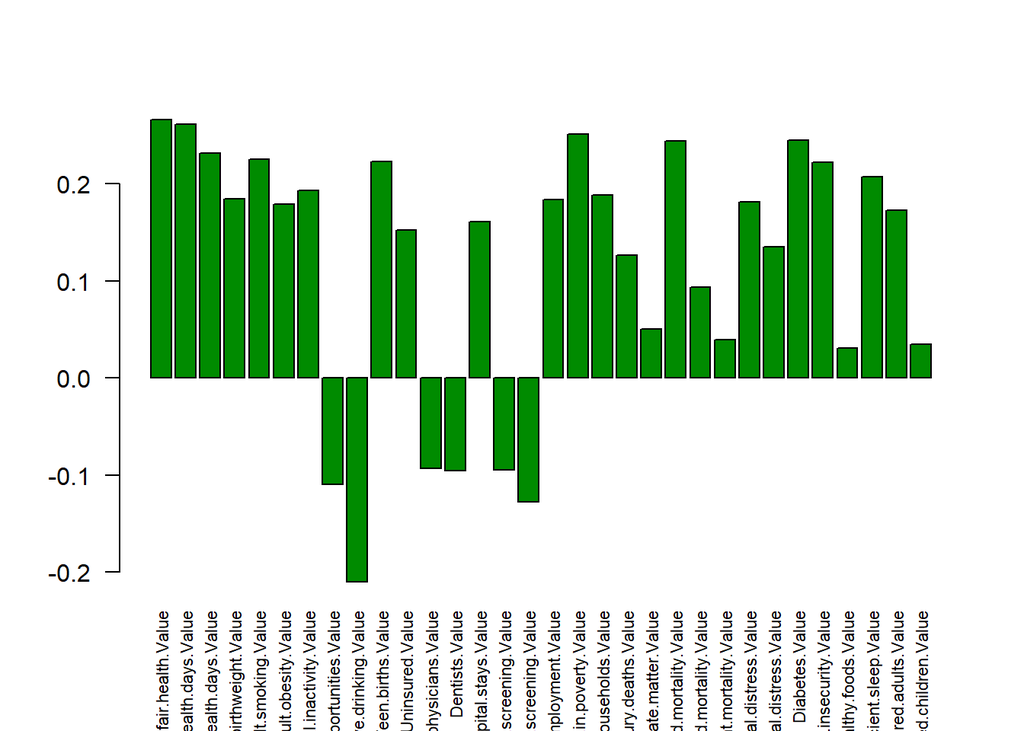

```r
barplot(-pca$rotation[,1], las=2, col="green4", cex.names = 0.7 )
text(1,1,"test", srt=45)
```

This component is capturing the information about health, % disease, % bad habits like smoking and obesity, also this component is capturing information about poverty

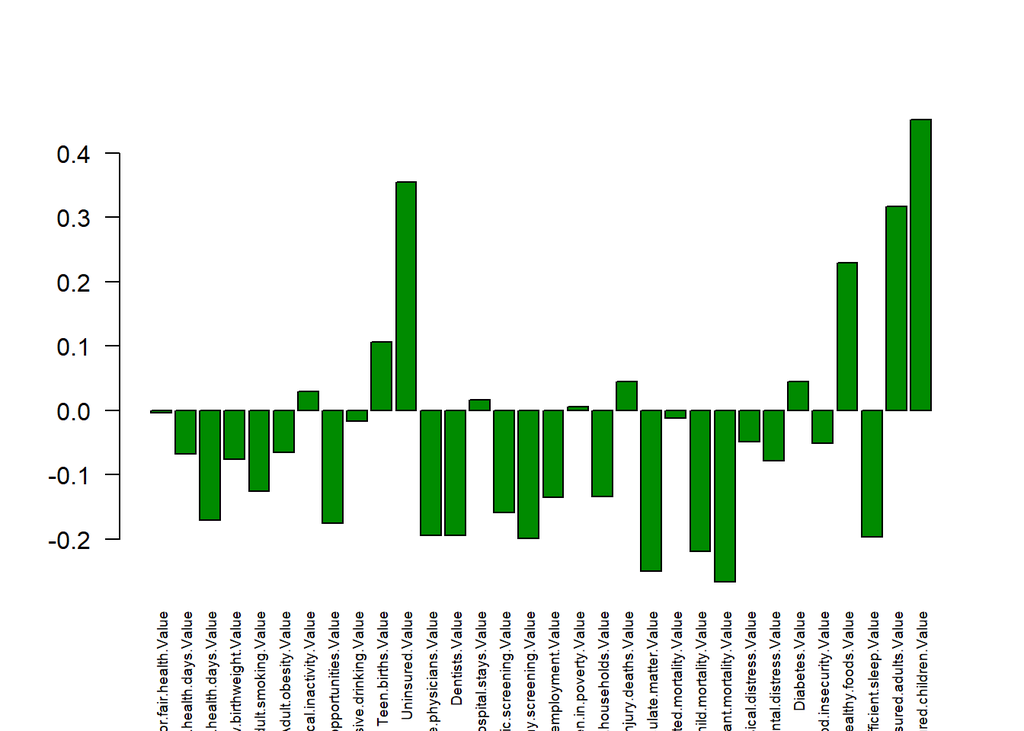

```r
barplot(-pca$rotation[,2], las=2, col="green4", cex.names = 0.6)
```

This component seem to be capturing the info about insures in adult and children, this information is realtive to the social-economic factor, becauses a person that is not secure generally is poverty people (sadly)

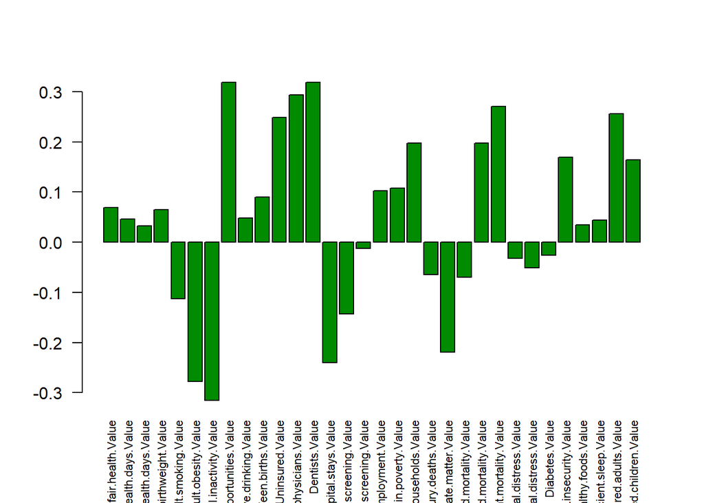

```r
barplot(-pca$rotation[,3], las=2, col="green4", cex.names = 0.7)
```

This component is a little more difficult to interpret

## Plotting the Components

We will plotting the components to see graphically how the 2 principal component are clustering our data

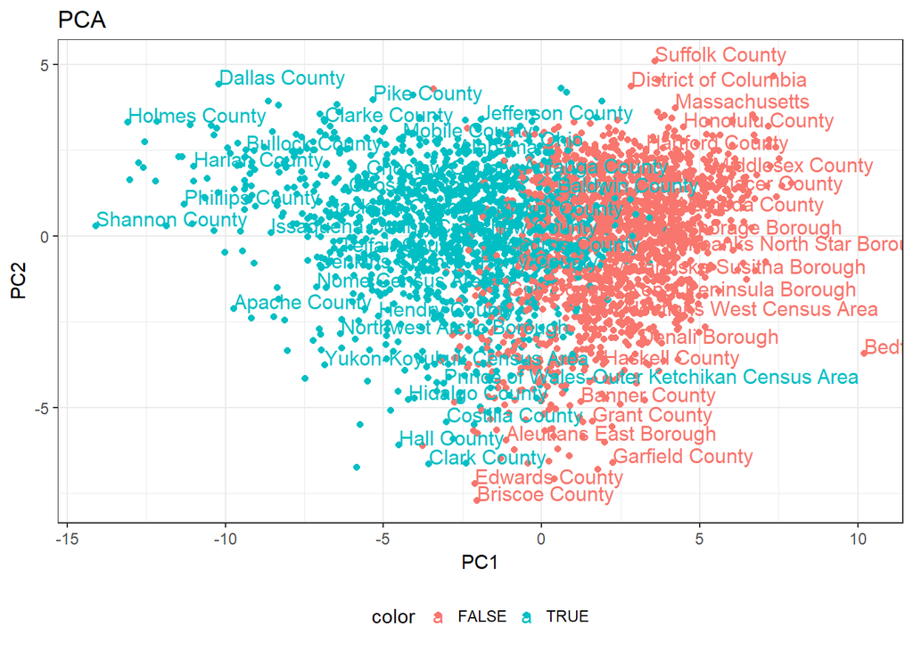

```r
shares <- Dataset$COUNTYCODE
color <- Dataset_num$Poor.physical.health.days.Value > 3.8
qplot(pca$x[,1],pca$x[,2], label=names, col=color) +
  labs(title="PCA", x="PC1", y="PC2") +
  theme_bw() + theme(legend.position="bottom") + geom_text(size=4, hjust=0, vjust=0, check_overlap = T)
```

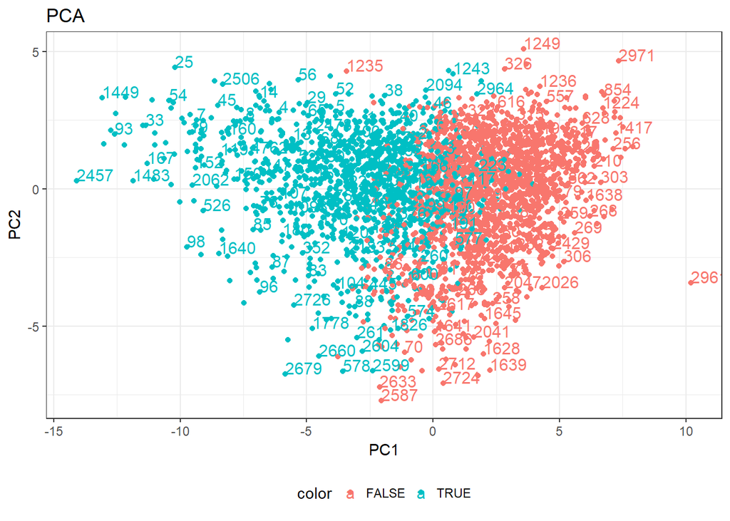

```r
qplot(pca$x[,1],pca$x[,2], label=1:nrow(Dataset), col=color) +
  labs(title="PCA", x="PC1", y="PC2") +
  theme_bw() + theme(legend.position="bottom") + geom_text(size=4, hjust=0, vjust=0, check_overlap = T)
```

As we can see, The PCA had split our data in 2 clusterings, we believe that by county and its health condition, the county with better health conditions are in rigth and the worse are in the left.

```r
cbind(rbind(as.vector(names)[2166], as.vector(names)[2460]),rbind(Dataset_num[2166,], Dataset_num[2460,]))
```

```
##      rbind(as.vector(names)[2166], as.vector(names)[2460])
## 2166                                          Adair County
## 2460                                          Sully County
##      Poor.or.fair.health.Value Poor.physical.health.days.Value
## 2166                      0.29                             5.9
## 2460                      0.08                             2.2
##      Poor.mental.health.days.Value Low.birthweight.Value
## 2166                           5.4                  0.08
## 2460                           2.1                  0.08
##      Adult.smoking.Value Adult.obesity.Value Physical.inactivity.Value
## 2166               0.293               0.382                     0.383
## 2460               0.130               0.321                     0.285
##      Access.to.exercise.opportunities.Value Excessive.drinking.Value
## 2166                                  0.191                    0.110
## 2460                                  1.000                    0.198
##      Teen.births.Value Uninsured.Value Primary.care.physicians.Value
## 2166              68.4           0.266                            36
## 2460              30.4           0.151                             0
##      Dentists.Value Preventable.hospital.stays.Value
## 2166             23                        124.43000
## 2460              0                         50.41222
##      Diabetic.screening.Value Mammography.screening.Value
## 2166                     0.52                        0.52
## 2460                     0.82                        0.62
##      Unemployment.Value Children.in.poverty.Value
## 2166              0.076                     0.367
## 2460              0.028                     0.067
##      Children.in.single.parent.households.Value Injury.deaths.Value
## 2166                                      0.340                97.1
## 2460                                      0.155                 0.0
##      Air.pollution...particulate.matter.Value
## 2166                                    10.95
## 2460                                    10.04
##      Premature.age.adjusted.mortality.Value Child.mortality.Value
## 2166                                  519.8                 105.3
## 2460                                  385.6                   0.0
##      Infant.mortality.Value Frequent.physical.distress.Value
## 2166                    9.2                              0.2
## 2460                    0.0                              0.1
##      Frequent.mental.distress.Value Diabetes.Value Food.insecurity.Value
## 2166                            0.2          0.161                 0.191
## 2460                            0.1          0.085                 0.096
##      Limited.access.to.healthy.foods.Value Insufficient.sleep.Value
## 2166                                 0.037                     0.41
## 2460                                 0.231                     0.24
##      Uninsured.adults.Value Uninsured.children.Value
## 2166                  0.335                    0.117
## 2460                  0.169                    0.107
```

We can see how different this counties are, let’s examine a few of them, the **Adair County** has a greater average of people that reported physically unhealthy days per month, greater obesity and smoking index, children in poverty, premature age died, we could say that this county is more unhealthy that the **Sully County**

Checking the information about this 2 counties on wikipedia, we discover that the **Adair County(OK)** according the 2010 census: *The median income for a household in the county was $27,258, and the median income for a family was $32,930. Males had a median income of $28,370 versus $23,384 for females. The per capita income for the county was $13,560. About 25.3 percent of families and 27.8 percent of the population were below the poverty line* whereas the **Sully County(SD):** *The median income for a household in the county was $48,958 and the median income for a family was $58,875. Males had a median income of $34,375 versus $29,087 for females. The per capita income for the county was $26,596. About 4.4% of families and 8.0% of the population were below the poverty line.*

**So our PCA is clustering the poorest and the richiest counties in a good manner, sadly as we can hope the poorest counties has the worse health indicators.**

Finally the biplot

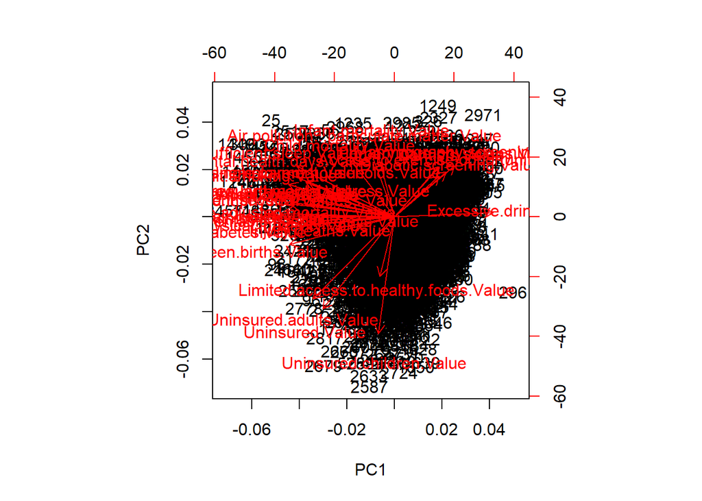

```r
biplot(pca)
```

We can see that there is individuals which clearly groups most of the variables, that is what defines our clusters

### Clustering with the kmeans methods

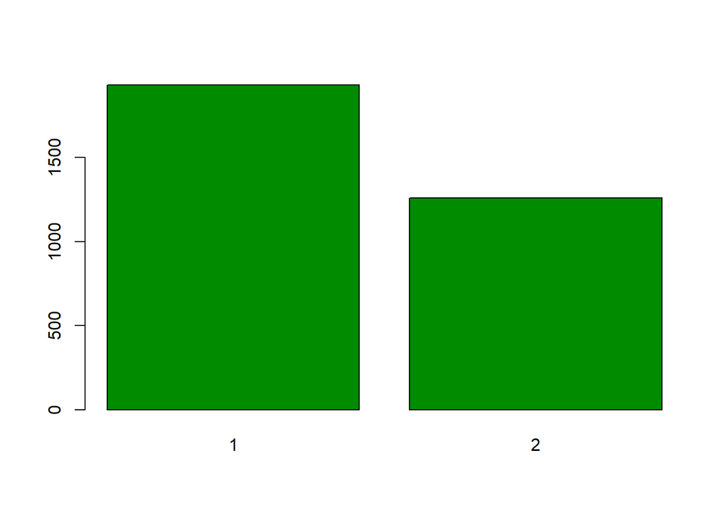

```r
X = scale(Dataset_num)

fit = kmeans(X, centers=2, nstart=100)
groups = fit$cluster
barplot(table(groups), col="green4")
```

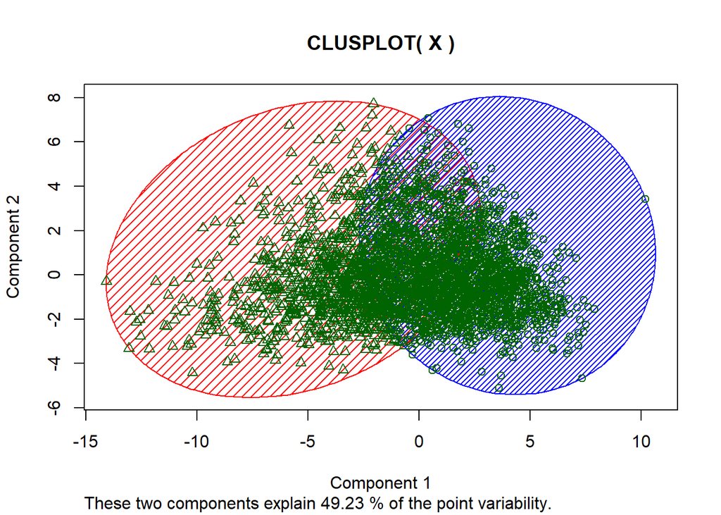

```r
clusplot(X, fit$cluster,color=TRUE,shade=TRUE,lines=0)
```

```r
table(groups)
```

```
## groups
##    1    2
## 1932 1259
```

Now let’s check if the point selected befores has clustering properly:

```r
groups[2166]
```

```
## [1] 2
```

```r
groups[2460]
```

```
## [1] 1
```

we note that this point are in diferent cluster like we saw before. So in cluster 1 we have the counties with better health conditions and in cluster 2 the worse ones.

### Extracting Silhouette Information from Clustering

```r
d <- dist(X, method="euclidean")
sil = silhouette(groups,d)
summary(sil)
```

```
## Silhouette of 3191 units in 2 clusters from silhouette.default(x = groups, dist = d) :
##  Cluster sizes and average silhouette widths:
##      1932      1259
## 0.2884552 0.1393067
## Individual silhouette widths:
##     Min.  1st Qu.   Median     Mean  3rd Qu.     Max.
## -0.08287  0.13920  0.23811  0.22961  0.33565  0.46140
```

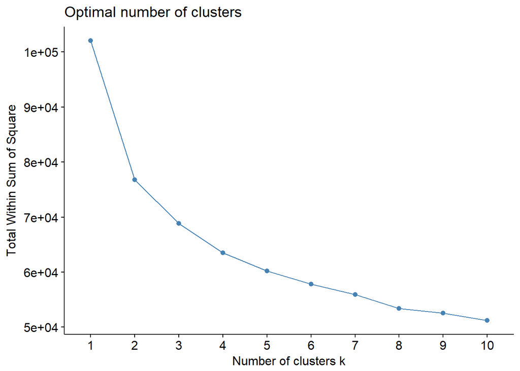

```r
fviz_nbclust(X, kmeans, method = 'wss')
```

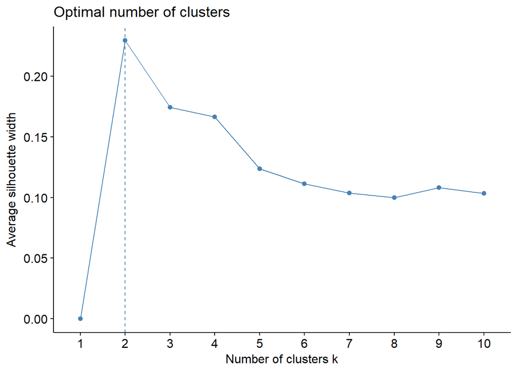

```r
fviz_nbclust(X, kmeans, method = 'silhouette')
```

The graphic show us when k = 2, suggesting that’s the optimal number of clusters, as we saw in PCA

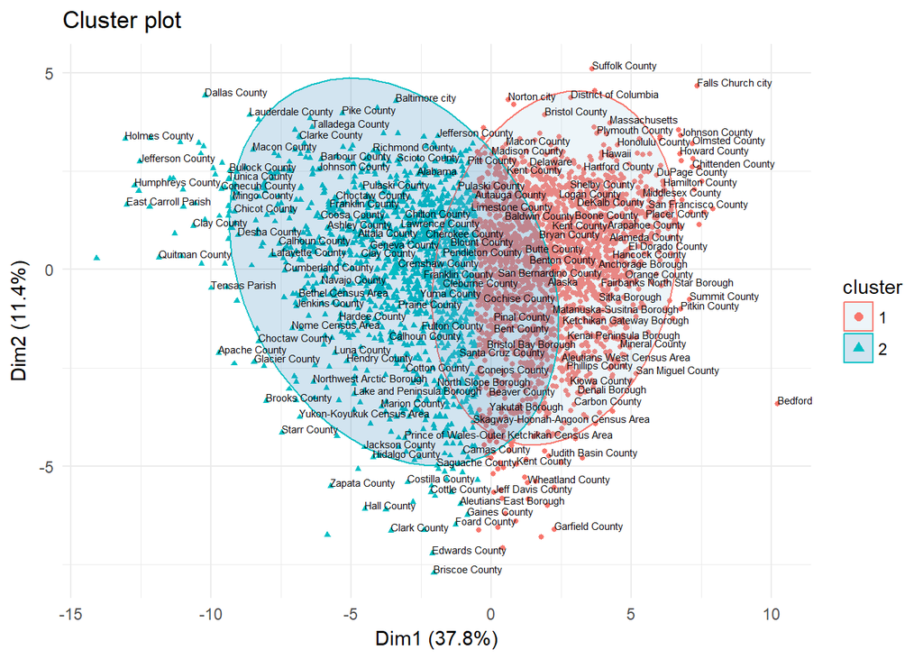

```r
fviz_cluster(fit, data = X, geom = c("point"),ellipse.type = 'norm', pointsize=1)+
  theme_minimal()+geom_text(label=names,hjust=0, vjust=0,size=2,check_overlap = T)+scale_fill_brewer(palette="Paired")
```

```r
fit.km <- eclust(X, "kmeans", k = 2, nboot = 100)
```

[figure not shown]

```
##   cluster size ave.sil.width
## 1       1 1932          0.29
## 2       2 1259          0.14
```

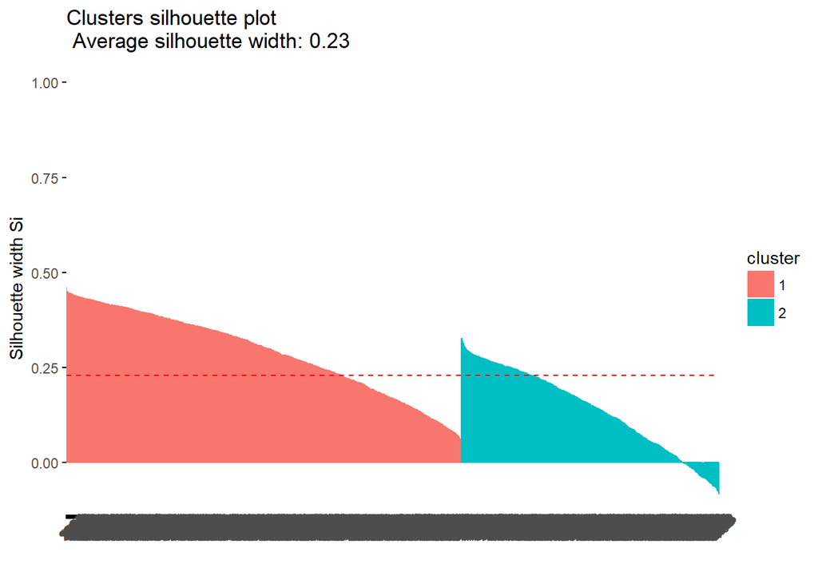

```r
fviz_silhouette(fit.km, d)
```

```r
centers=fit.km$centers
centers
```

```
##   Poor.or.fair.health.Value Poor.physical.health.days.Value
## 1                -0.6229610                      -0.6030003
## 2                 0.9559656                       0.9253349
##   Poor.mental.health.days.Value Low.birthweight.Value Adult.smoking.Value
## 1                    -0.5290033            -0.4309661          -0.5112970
## 2                     0.8117827             0.6613395           0.7846114
##   Adult.obesity.Value Physical.inactivity.Value
## 1          -0.3966521                -0.4760170
## 2           0.6086829                 0.7304724
##   Access.to.exercise.opportunities.Value Excessive.drinking.Value
## 1                              0.2677355                0.5117162
## 2                             -0.4108539               -0.7852547
##   Teen.births.Value Uninsured.Value Primary.care.physicians.Value
## 1        -0.5396746      -0.3727393                     0.2129545
## 2         0.8281583       0.5719876                    -0.3267895
##   Dentists.Value Preventable.hospital.stays.Value Diabetic.screening.Value
## 1      0.2172049                       -0.3647613                0.1905982
## 2     -0.3333121                        0.5597450               -0.2924828
##   Mammography.screening.Value Unemployment.Value Children.in.poverty.Value
## 1                   0.2947083         -0.3788600                -0.5742429
## 2                  -0.4522450          0.5813801                 0.8812052
##   Children.in.single.parent.households.Value Injury.deaths.Value
## 1                                 -0.4158752          -0.2700653
## 2                                  0.6381819           0.4144291
##   Air.pollution...particulate.matter.Value
## 1                               -0.1228770
## 2                                0.1885611
##   Premature.age.adjusted.mortality.Value Child.mortality.Value
## 1                             -0.5580392            -0.2060107
## 2                              0.8563397             0.3161340
##   Infant.mortality.Value Frequent.physical.distress.Value
## 1            -0.09215792                       -0.3314665
## 2             0.14142106                        0.5086523
##   Frequent.mental.distress.Value Diabetes.Value Food.insecurity.Value
## 1                     -0.1977985     -0.5549613            -0.4875952
## 2                      0.3035319      0.8516165             0.7482398
##   Limited.access.to.healthy.foods.Value Insufficient.sleep.Value
## 1                           -0.04248808               -0.4678223
## 2                            0.06520014                0.7178973
##   Uninsured.adults.Value Uninsured.children.Value
## 1             -0.4205496              -0.08631801
## 2              0.6453550               0.13245941
```

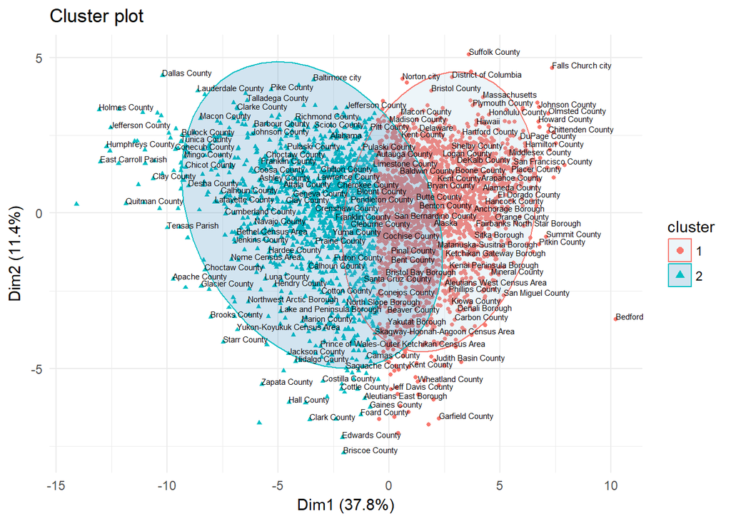

```r
groups = fit.km$cluster
fviz_cluster(fit.km, data = X, geom = c("point"),ellipse.type = 'norm', pointsize=1)+
  theme_minimal()+geom_text(label=names,hjust=0, vjust=0,size=2,check_overlap = T)+scale_fill_brewer(palette="Paired")
```

## Factor Analysis

If in PCA each component is orthogonal linear combinations of the variables to maximize the variance, in FA we have that factors are a linear combination of the underlying *latent* variables to maximize the shared variance among the variables.

First at we need to decide the optimum number of factor to extract, let’s do it with the eigenvalues

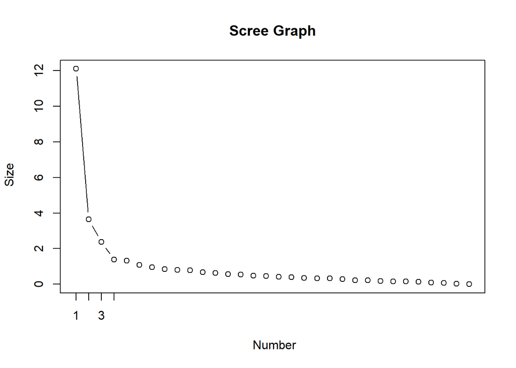

```r
ev <- eigen(cor(Dataset_num)) # get eigenvalues
plot(ev$values, xlab = ' Number', ylab = ' Size', main = 'Scree Graph', type = 'b', xaxt = 'n')
axis(1, at = seq(1, 4, by = 1))
```

The grahp show us that 2,3 or 4 factors are required, but let’s try with 2 factors.

Lets Apply the Factor Analysis

```r
X <- Dataset_num
x.f <- factanal(X, factors = 2, rotation="none", scores="regression", lower = 0.01)
x.f
```

```
##
## Call:
## factanal(x = X, factors = 2, scores = "regression", rotation = "none",     lower = 0.01)
##
## Uniquenesses:
##                  Poor.or.fair.health.Value
##                                      0.106
##            Poor.physical.health.days.Value
##                                      0.099
##              Poor.mental.health.days.Value
##                                      0.229
##                      Low.birthweight.Value
##                                      0.633
##                        Adult.smoking.Value
##                                      0.322
##                        Adult.obesity.Value
##                                      0.633
##                  Physical.inactivity.Value
##                                      0.636
##     Access.to.exercise.opportunities.Value
##                                      0.903
##                   Excessive.drinking.Value
##                                      0.489
##                          Teen.births.Value
##                                      0.402
##                            Uninsured.Value
##                                      0.010
##              Primary.care.physicians.Value
##                                      0.917
##                             Dentists.Value
##                                      0.909
##           Preventable.hospital.stays.Value
##                                      0.741
##                   Diabetic.screening.Value
##                                      0.862
##                Mammography.screening.Value
##                                      0.776
##                         Unemployment.Value
##                                      0.555
##                  Children.in.poverty.Value
```

[output cut: 58 more lines]

```
## Diabetes.Value                              0.609   0.554
## Food.insecurity.Value                       0.572   0.496
## Limited.access.to.healthy.foods.Value      -0.128   0.263
## Insufficient.sleep.Value                    0.716   0.291
## Uninsured.adults.Value                              0.993
## Uninsured.children.Value                   -0.509   0.734
##
##                Factor1 Factor2
## SS loadings      7.896   6.613
## Proportion Var   0.247   0.207
## Cumulative Var   0.247   0.453
##
## Test of the hypothesis that 2 factors are sufficient.
## The chi square statistic is 30018.78 on 433 degrees of freedom.
## The p-value is 0
```

```r
cbind(x.f$loadings, x.f$uniquenesses)
```

```
##                                                Factor1     Factor2
## Poor.or.fair.health.Value                   0.70229336  0.63308866
## Poor.physical.health.days.Value             0.77595562  0.54697110
## Poor.mental.health.days.Value               0.79664387  0.36909851
## Low.birthweight.Value                       0.50075947  0.34124893
## Adult.smoking.Value                         0.76507267  0.30427228
## Adult.obesity.Value                         0.57799243  0.18101584
## Physical.inactivity.Value                   0.51751469  0.31023193
## Access.to.exercise.opportunities.Value     -0.19162698 -0.24578486
## Excessive.drinking.Value                   -0.53229009 -0.47651439
## Teen.births.Value                           0.42862845  0.64396660
## Uninsured.Value                            -0.13475697  0.98676911
## Primary.care.physicians.Value              -0.10687851 -0.26812018
## Dentists.Value                             -0.10597131 -0.28232434
## Preventable.hospital.stays.Value            0.44656620  0.24390776
## Diabetic.screening.Value                   -0.07268531 -0.36442274
## Mammography.screening.Value                -0.14755006 -0.44948386
## Unemployment.Value                          0.59787531  0.29540611
## Children.in.poverty.Value                   0.62220060  0.60739153
## Children.in.single.parent.households.Value  0.57341441  0.32585404
## Injury.deaths.Value                         0.29749573  0.25455928
## Air.pollution...particulate.matter.Value    0.38616603 -0.19866631
## Premature.age.adjusted.mortality.Value      0.65173069  0.44959949
## Child.mortality.Value                       0.37350134  0.07354783
## Infant.mortality.Value                      0.25316685 -0.03473127
## Frequent.physical.distress.Value            0.56419251  0.29906104
## Frequent.mental.distress.Value              0.45980503  0.14334347
## Diabetes.Value                              0.60927027  0.55394811
## Food.insecurity.Value                       0.57233136  0.49570352
## Limited.access.to.healthy.foods.Value      -0.12791864  0.26283521
## Insufficient.sleep.Value                    0.71630769  0.29138462
## Uninsured.adults.Value                     -0.03780003  0.99340685
## Uninsured.children.Value                   -0.50856407  0.73373201
##
## Poor.or.fair.health.Value                  0.10597867
## Poor.physical.health.days.Value            0.09871096
## Poor.mental.health.days.Value              0.22912748
## Low.birthweight.Value                      0.63282536
## Adult.smoking.Value                        0.32201157
## Adult.obesity.Value                        0.63319168
```

[output cut: 11 more lines]

```
## Children.in.poverty.Value                  0.24390729
## Children.in.single.parent.households.Value 0.56509394
## Injury.deaths.Value                        0.84691245
## Air.pollution...particulate.matter.Value   0.81153254
## Premature.age.adjusted.mortality.Value     0.37310870
## Child.mortality.Value                      0.85529410
## Infant.mortality.Value                     0.93491415
## Frequent.physical.distress.Value           0.59233418
## Frequent.mental.distress.Value             0.76807692
## Diabetes.Value                             0.32194544
## Food.insecurity.Value                      0.42669514
## Limited.access.to.healthy.foods.Value      0.91444243
## Insufficient.sleep.Value                   0.40200603
## Uninsured.adults.Value                     0.01171403
## Uninsured.children.Value                   0.20299539
```

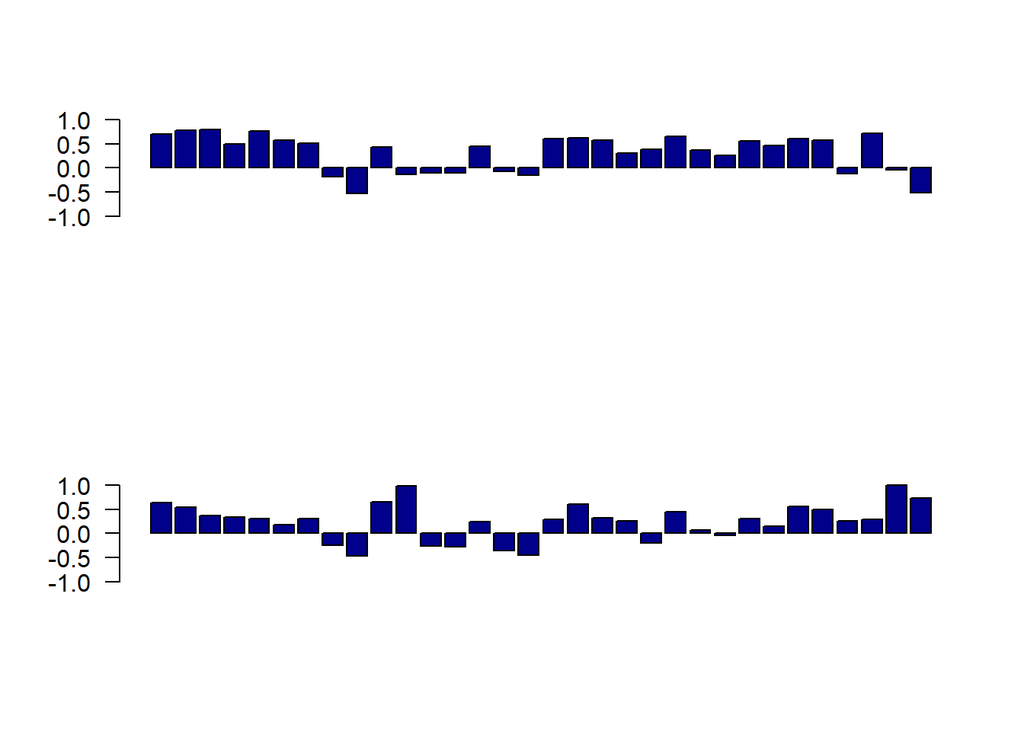

```r
par(mfrow=c(2,1))
barplot(x.f$loadings[,1], names=F, las=2, col="darkblue", ylim = c(-1, 1))
barplot(x.f$loadings[,2], names=F, las=2, col="darkblue", ylim = c(-1, 1))
```

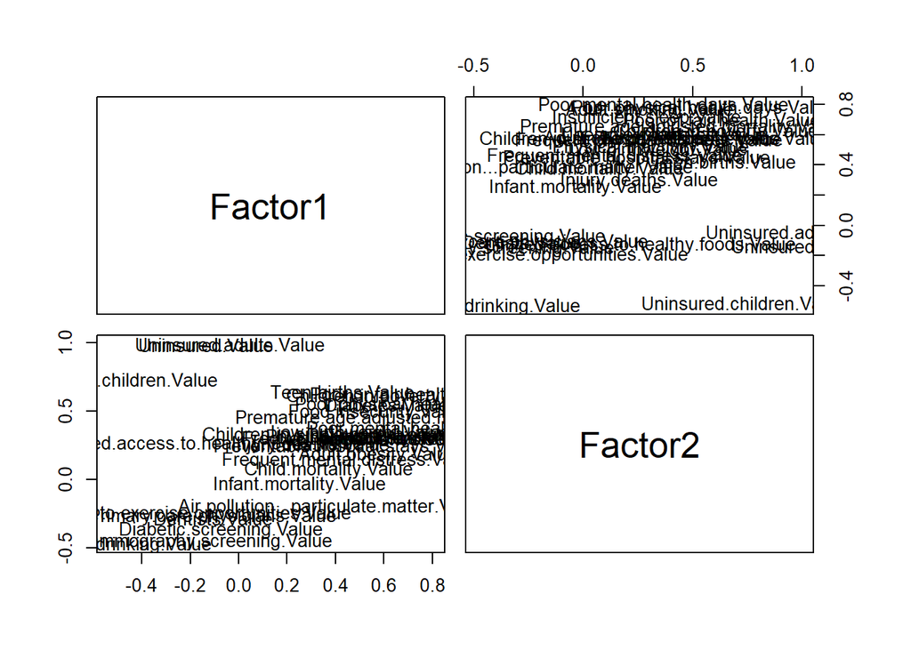

```r
pairs(x.f$loadings, panel = function(x,y) text(x,y, labels=names(X)))
```

There are 2 unobserved latent factors that underly the observed variables, **Factor 1** is influenced by *Poor.or.fair.health.Value, Poor.physical.health.days.Value, Children.in.poverty.Value, Adult.smoking.Value, Adult.obesity.Value, Premature.age.adjusted.mortality.Value* so it seems that this factor concentrate the information of health habits; the **Factor 2** is influenced by *Uninsured.adults.Value, Uninsured.children.Value, Uninsured.Value, Children.in.poverty.Value* so mainly information socioeconomic.

Let’s examine a little more, we will apply the varimax rotation, to check if is there any differences:

```r
x.f <- factanal(X, factors = 2, rotation="varimax", scores="regression", lower = 0.01)
x.f
```

```
##
## Call:
## factanal(x = X, factors = 2, scores = "regression", rotation = "varimax",     lower = 0.01)
##
## Uniquenesses:
##                  Poor.or.fair.health.Value
##                                      0.106
##            Poor.physical.health.days.Value
##                                      0.099
##              Poor.mental.health.days.Value
##                                      0.229
##                      Low.birthweight.Value
##                                      0.633
##                        Adult.smoking.Value
##                                      0.322
##                        Adult.obesity.Value
##                                      0.633
##                  Physical.inactivity.Value
##                                      0.636
##     Access.to.exercise.opportunities.Value
##                                      0.903
##                   Excessive.drinking.Value
##                                      0.489
##                          Teen.births.Value
##                                      0.402
##                            Uninsured.Value
##                                      0.010
##              Primary.care.physicians.Value
##                                      0.917
##                             Dentists.Value
##                                      0.909
##           Preventable.hospital.stays.Value
##                                      0.741
##                   Diabetic.screening.Value
##                                      0.862
##                Mammography.screening.Value
##                                      0.776
##                         Unemployment.Value
##                                      0.555
##                  Children.in.poverty.Value
```

[output cut: 58 more lines]

```
## Diabetes.Value                              0.753   0.333
## Food.insecurity.Value                       0.700   0.289
## Limited.access.to.healthy.foods.Value               0.290
## Insufficient.sleep.Value                    0.772
## Uninsured.adults.Value                      0.278   0.954
## Uninsured.children.Value                   -0.251   0.857
##
##                Factor1 Factor2
## SS loadings     10.292   4.218
## Proportion Var   0.322   0.132
## Cumulative Var   0.322   0.453
##
## Test of the hypothesis that 2 factors are sufficient.
## The chi square statistic is 30018.78 on 433 degrees of freedom.
## The p-value is 0
```

```r
cbind(x.f$loadings, x.f$uniquenesses)
```

```
##                                                Factor1      Factor2
## Poor.or.fair.health.Value                   0.86636336  0.378723836
## Poor.physical.health.days.Value             0.90903794  0.273741721
## Poor.mental.health.days.Value               0.87245834  0.098445987
## Low.birthweight.Value                       0.58293484  0.165522966
## Adult.smoking.Value                         0.82201977  0.046918018
## Adult.obesity.Value                         0.60557663 -0.010905270
## Physical.inactivity.Value                   0.58903013  0.130800645
## Access.to.exercise.opportunities.Value     -0.25947590 -0.172636476
## Excessive.drinking.Value                   -0.65559371 -0.283893621
## Teen.births.Value                           0.61015871  0.475522530
## Uninsured.Value                             0.18396729  0.978789437
## Primary.care.physicians.Value              -0.18612798 -0.220607844
## Dentists.Value                             -0.18975578 -0.234370849
## Preventable.hospital.stays.Value            0.50075866  0.090294721
## Diabetic.screening.Value                   -0.18411850 -0.322780835
## Mammography.screening.Value                -0.28202644 -0.379826076
## Unemployment.Value                          0.66058804  0.091340545
## Children.in.poverty.Value                   0.78225432  0.379652766
## Children.in.single.parent.households.Value  0.64700209  0.127957945
## Injury.deaths.Value                         0.36269256  0.147506746
## Air.pollution...particulate.matter.Value    0.30359996 -0.310515007
## Premature.age.adjusted.mortality.Value      0.76040896  0.220614618
## Child.mortality.Value                       0.37760394 -0.048247314
## Infant.mortality.Value                      0.22921928 -0.112952377
## Frequent.physical.distress.Value            0.62978613  0.105451972
## Frequent.mental.distress.Value              0.48154079 -0.009300037
## Diabetes.Value                              0.75309843  0.333033821
## Food.insecurity.Value                       0.69964700  0.289446444
## Limited.access.to.healthy.foods.Value      -0.03830801  0.289789622
## Insufficient.sleep.Value                    0.77168105  0.050100467
## Uninsured.adults.Value                      0.27805361  0.954448642
## Uninsured.children.Value                   -0.25064537  0.856841280
##
## Poor.or.fair.health.Value                  0.10597867
## Poor.physical.health.days.Value            0.09871096
## Poor.mental.health.days.Value              0.22912748
## Low.birthweight.Value                      0.63282536
## Adult.smoking.Value                        0.32201157
## Adult.obesity.Value                        0.63319168
```

[output cut: 11 more lines]

```
## Children.in.poverty.Value                  0.24390729
## Children.in.single.parent.households.Value 0.56509394
## Injury.deaths.Value                        0.84691245
## Air.pollution...particulate.matter.Value   0.81153254
## Premature.age.adjusted.mortality.Value     0.37310870
## Child.mortality.Value                      0.85529410
## Infant.mortality.Value                     0.93491415
## Frequent.physical.distress.Value           0.59233418
## Frequent.mental.distress.Value             0.76807692
## Diabetes.Value                             0.32194544
## Food.insecurity.Value                      0.42669514
## Limited.access.to.healthy.foods.Value      0.91444243
## Insufficient.sleep.Value                   0.40200603
## Uninsured.adults.Value                     0.01171403
## Uninsured.children.Value                   0.20299539
```

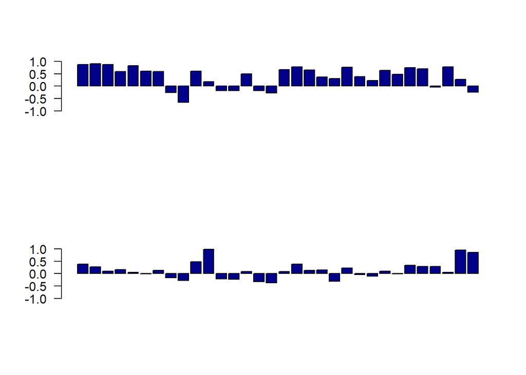

```r
par(mfrow=c(2,1))
barplot(x.f$loadings[,1], names=F, las=2, col="darkblue", ylim = c(-1, 1))
barplot(x.f$loadings[,2], names=F, las=2, col="darkblue", ylim = c(-1, 1))
```

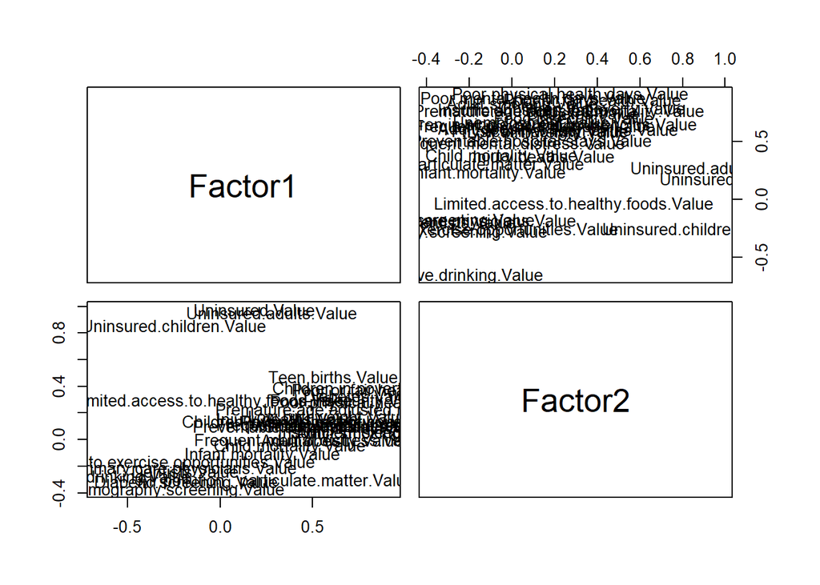

```r
pairs(x.f$loadings, panel = function(x,y) text(x,y, labels=names(X)))
```

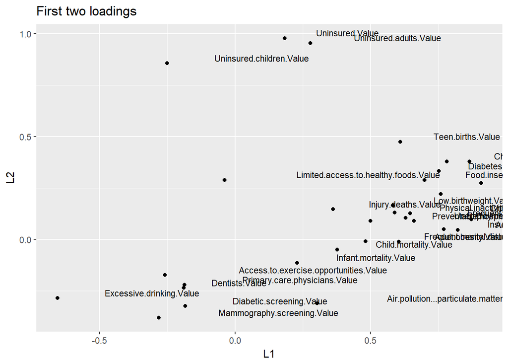

```r
qplot(x.f$loadings[,1], x.f$loadings[,2], label=names(X)) +
  labs(title="First two loadings", x="L1", y="L2") +
  geom_text(size=3, hjust=-.5, vjust=-.3)
```

Let’s Explore promax rotation:

```r
x.f <- factanal(X, factors = 2, rotation="promax", scores="regression", lower = 0.01)
x.f
```

```
##
## Call:
## factanal(x = X, factors = 2, scores = "regression", rotation = "promax",     lower = 0.01)
##
## Uniquenesses:
##                  Poor.or.fair.health.Value
##                                      0.106
##            Poor.physical.health.days.Value
##                                      0.099
##              Poor.mental.health.days.Value
##                                      0.229
##                      Low.birthweight.Value
##                                      0.633
##                        Adult.smoking.Value
##                                      0.322
##                        Adult.obesity.Value
##                                      0.633
##                  Physical.inactivity.Value
##                                      0.636
##     Access.to.exercise.opportunities.Value
##                                      0.903
##                   Excessive.drinking.Value
##                                      0.489
##                          Teen.births.Value
##                                      0.402
##                            Uninsured.Value
##                                      0.010
##              Primary.care.physicians.Value
##                                      0.917
##                             Dentists.Value
##                                      0.909
##           Preventable.hospital.stays.Value
##                                      0.741
##                   Diabetic.screening.Value
##                                      0.862
##                Mammography.screening.Value
##                                      0.776
##                         Unemployment.Value
##                                      0.555
##                  Children.in.poverty.Value
```

[output cut: 63 more lines]

```
## Uninsured.children.Value                   -0.307   0.928
##
##                Factor1 Factor2
## SS loadings     10.802   3.478
## Proportion Var   0.338   0.109
## Cumulative Var   0.338   0.446
##
## Factor Correlations:
##         Factor1 Factor2
## Factor1   1.000   0.278
## Factor2   0.278   1.000
##
## Test of the hypothesis that 2 factors are sufficient.
## The chi square statistic is 30018.78 on 433 degrees of freedom.
## The p-value is 0
```

```r
cbind(x.f$loadings, x.f$uniquenesses)
```

```
##                                                Factor1     Factor2
## Poor.or.fair.health.Value                   0.88027654  0.17834776
## Poor.physical.health.days.Value             0.93031365  0.06180520
## Poor.mental.health.days.Value               0.90175014 -0.10720844
## Low.birthweight.Value                       0.59711928  0.02947837
## Adult.smoking.Value                         0.85209364 -0.14747384
## Adult.obesity.Value                         0.63018751 -0.15473420
## Physical.inactivity.Value                   0.60533159 -0.00716489
## Access.to.exercise.opportunities.Value     -0.26044524 -0.11343339
## Excessive.drinking.Value                   -0.66626756 -0.13222838
## Teen.births.Value                           0.60868103  0.33725741
## Uninsured.Value                             0.13840378  0.94852419
## Primary.care.physicians.Value              -0.18159700 -0.17946328
## Dentists.Value                             -0.18462541 -0.19255374
## Preventable.hospital.stays.Value            0.51574616 -0.02728126
## Diabetic.screening.Value                   -0.17398979 -0.28351007
## Mammography.screening.Value                -0.27270070 -0.31810554
## Unemployment.Value                          0.68185915 -0.06414244
## Children.in.poverty.Value                   0.79278091  0.19924520
## Children.in.single.parent.households.Value  0.66575669 -0.02380095
## Injury.deaths.Value                         0.36911346  0.06347075
## Air.pollution...particulate.matter.Value    0.33241298 -0.38679318
## Premature.age.adjusted.mortality.Value      0.77865810  0.04321557
## Child.mortality.Value                       0.39518834 -0.13849775
## Infant.mortality.Value                      0.24441209 -0.16888162
## Frequent.physical.distress.Value            0.64907329 -0.04252997
## Frequent.mental.distress.Value              0.50114473 -0.12367813
## Diabetes.Value                              0.76498620  0.15890640
## Food.insecurity.Value                       0.71176846  0.12740500
## Limited.access.to.healthy.foods.Value      -0.05547815  0.30284093
## Insufficient.sleep.Value                    0.79958622 -0.13230446
## Uninsured.adults.Value                      0.23753686  0.90152755
## Uninsured.children.Value                   -0.30686302  0.92802533
##
## Poor.or.fair.health.Value                  0.10597867
## Poor.physical.health.days.Value            0.09871096
## Poor.mental.health.days.Value              0.22912748
## Low.birthweight.Value                      0.63282536
## Adult.smoking.Value                        0.32201157
## Adult.obesity.Value                        0.63319168
```

[output cut: 11 more lines]

```
## Children.in.poverty.Value                  0.24390729
## Children.in.single.parent.households.Value 0.56509394
## Injury.deaths.Value                        0.84691245
## Air.pollution...particulate.matter.Value   0.81153254
## Premature.age.adjusted.mortality.Value     0.37310870
## Child.mortality.Value                      0.85529410
## Infant.mortality.Value                     0.93491415
## Frequent.physical.distress.Value           0.59233418
## Frequent.mental.distress.Value             0.76807692
## Diabetes.Value                             0.32194544
## Food.insecurity.Value                      0.42669514
## Limited.access.to.healthy.foods.Value      0.91444243
## Insufficient.sleep.Value                   0.40200603
## Uninsured.adults.Value                     0.01171403
## Uninsured.children.Value                   0.20299539
```

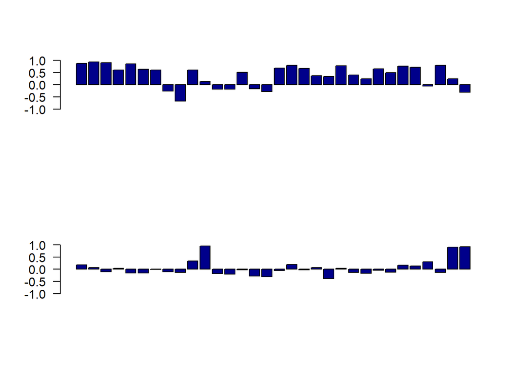

```r
par(mfrow=c(2,1))
barplot(x.f$loadings[,1], names=F, las=2, col="darkblue", ylim = c(-1, 1))
barplot(x.f$loadings[,2], names=F, las=2, col="darkblue", ylim = c(-1, 1))
```

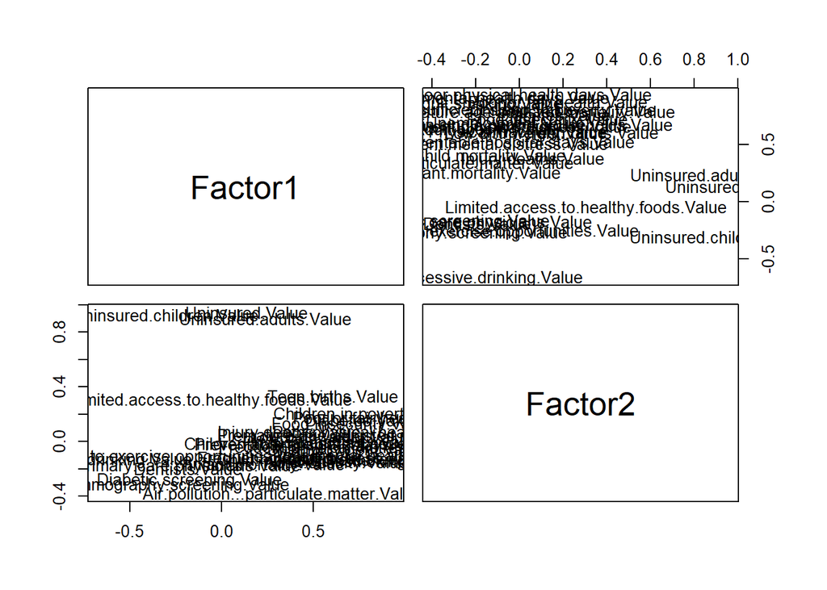

```r
pairs(x.f$loadings, panel = function(x,y) text(x,y, labels=names(X)))
```

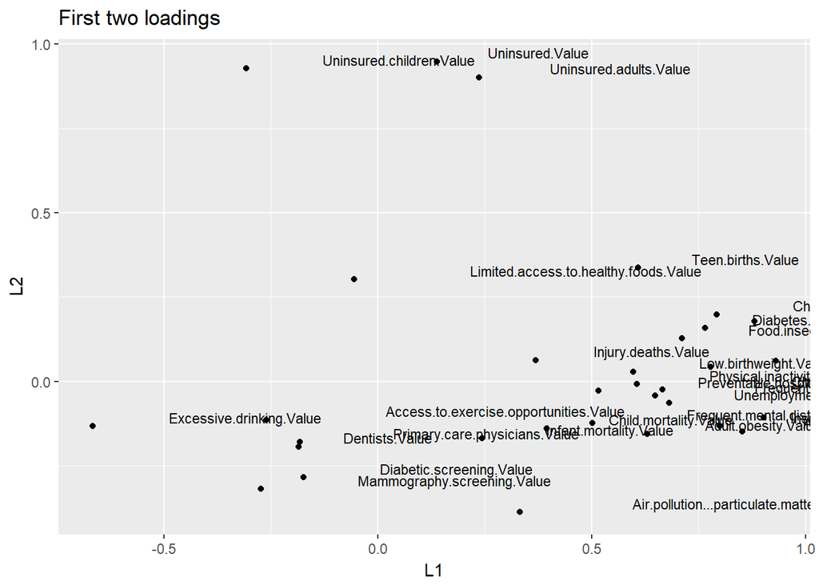

```r
qplot(x.f$loadings[,1], x.f$loadings[,2], label=names(X)) +
  labs(title="First two loadings", x="L1", y="L2") +
  geom_text(size=3, hjust=-.5, vjust=-.3)
```

Again, we can see with both rotations **varimax** and **promax** we have that the factor 1 is influenced mainly by health variables and factor 2 is influenced by variables like *Uninsured* that imply some socialeconomics considerations. Both of this factor represents and explains nearly 45% of the variance of the variables, is good enough to explain our data and discover pattern like what is inside each cluster, and why is this cluster created.

### Summary

PCA and FA are common methods of dimensionality reduction because both of them provides a way to reduce the dimension, The main differences in this methods are that while PCA is looking for lineal *real* correlation among the variables, FA is looking for *latent* patern in the data; In our case we apply both methods to a Dataset of health variables in the USA and this methods allow us to properly doing and Exploratory Data Analysis for this data and we could explain the cluster and associations among the variables. Finally to apply this method we should aware of its limitations.